# ch13

## Creating Data/time

### 1. What happens if you parse a string that contains invalid data?

```r
ymd(c("2010-10-10", "bananas"))
```

```
## [1] "2010-10-10" NA
```

It will show error in parse, and returns “NA”.

### 2. What does the tzone argument to today() do? Why is it important?

```r
today(tzone = "GMT")
```

```
## [1] "2018-01-27"
```

It is the timezone that are interested to find.

### 3. Use lubridate function to parse each of the following datas:

```r
d1 <- "January 1, 2010"
d2 <- "2015-Mar-07"
d3 <- "06-Jun-2017"
d4 <- c("August 19 (2015)", "July 1 (2015)")
d5 <- "12/30/14"

mdy(d1)
```

```
## [1] "2010-01-01"
```

```r
ymd(d2)
```

```
## [1] "2015-03-07"
```

```r
dmy(d3)
```

```
## [1] "2017-06-06"
```

```r
mdy(d4)
```

```
## [1] "2015-08-19" "2015-07-01"
```

```r
mdy(d5)
```

```
## [1] "2014-12-30"
```

## Data-time components

### 1. How does the distribution of flight times within a day change over the course of the year?

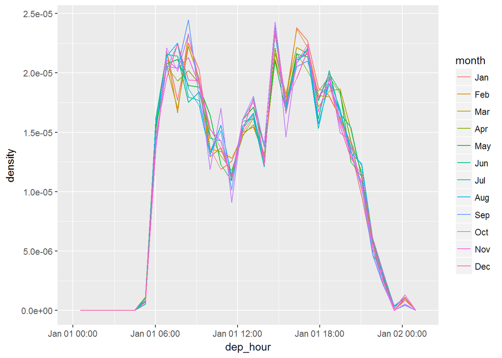

```r
library(nycflights13)

flights %>%
  mutate(date_time = make_datetime(year, month, day, sched_dep_time  %/% 100, sched_dep_time %% 100)) %>%
  select(date_time, flight) %>%
  mutate(dep_hour = update(date_time, yday = 1),
         month = month(date_time, label = T)) %>%
  ggplot(aes(dep_hour, ..density.., color = month)) +
  geom_freqpoly()
```

The trend is almost the same!

### 2. Compare dep_time, sched_dep_time, and dep_delay. Are the consisistent? Explain your finding.

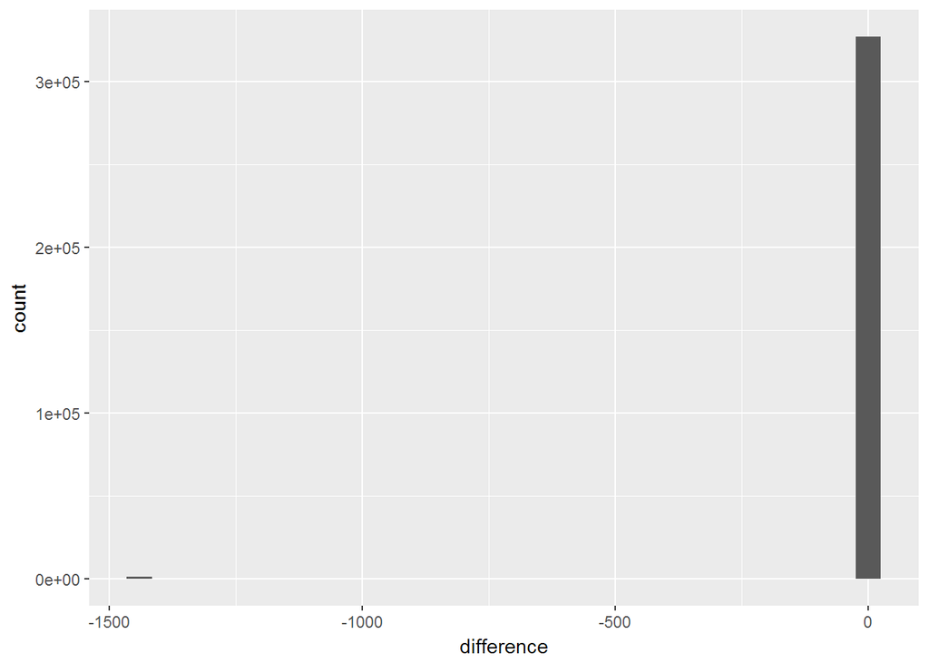

```r
convert_to_datetime <- function(year, month, day, time){
  make_datetime(year, month, day, time %/% 100, time %% 100)
}

flights %>%
  filter(!is.na(dep_time), !is.na(arr_time)) %>%
  mutate(sched_dep_datetime = convert_to_datetime(year, month, day, sched_dep_time),
         dep_datetime = convert_to_datetime(year, month, day, dep_time)) %>%
  select(sched_dep_datetime, dep_datetime, dep_delay, flight) %>%
  mutate(calcuated_delay = dep_datetime - sched_dep_datetime,
         difference = as.numeric(calcuated_delay/60 - dep_delay)) %>%
  ggplot(aes(difference)) +
  geom_histogram()
```

### 3. Compare air_time with the duration between the departure and arrival. Explain your findings.

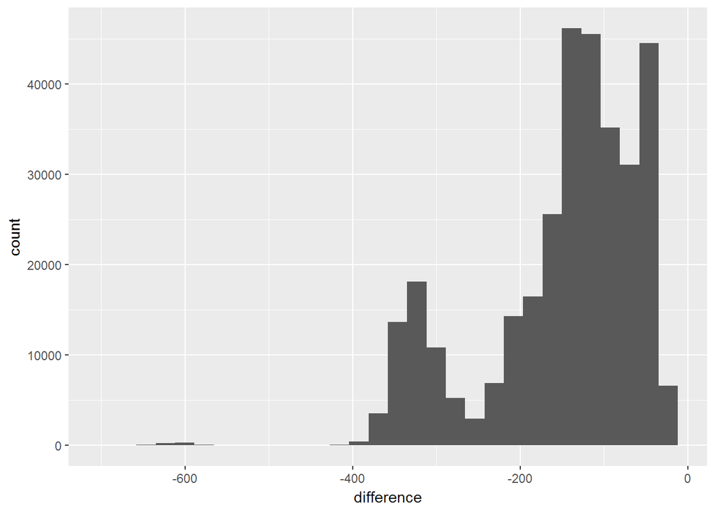

```r
flights %>%
  filter(!is.na(dep_time), !is.na(arr_time), !is.na(air_time)) %>%
  mutate(
  dep_datetime = convert_to_datetime(year, month, day, dep_time),
  arr_datetime = convert_to_datetime(year, month, day, arr_time)
  ) %>%
  select(dep_datetime, arr_datetime, air_time, flight) %>%
  mutate(air_time_calculated = arr_datetime - dep_datetime,
  difference = as.numeric(air_time_calculated/60 - air_time)) %>%
  ggplot(aes(difference)) +
  geom_histogram(bins = 30)
```

### 4. How does the average delay time change over the course of a day?

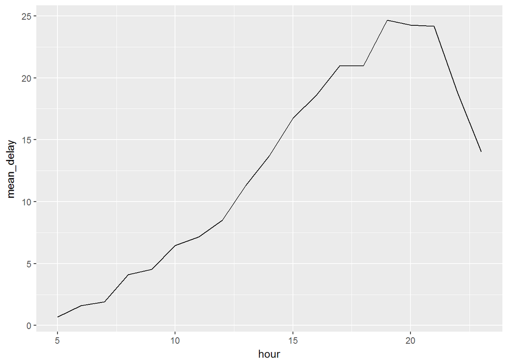

```r
flights %>%
  filter(!is.na(dep_time), !is.na(arr_time), !is.na(air_time)) %>%
  mutate(sched_dep_datetime = convert_to_datetime(year, month, day, sched_dep_time)) %>%
  select(sched_dep_datetime, dep_delay, flight) %>%
  mutate(hour = hour(sched_dep_datetime)) %>%
  group_by(hour) %>%
  summarise(mean_delay = mean(dep_delay)) %>%
  ggplot(aes(hour, mean_delay)) +
  geom_line()
```

### 5. On what day of the week should you leave if you want to minimize the chance of delay?

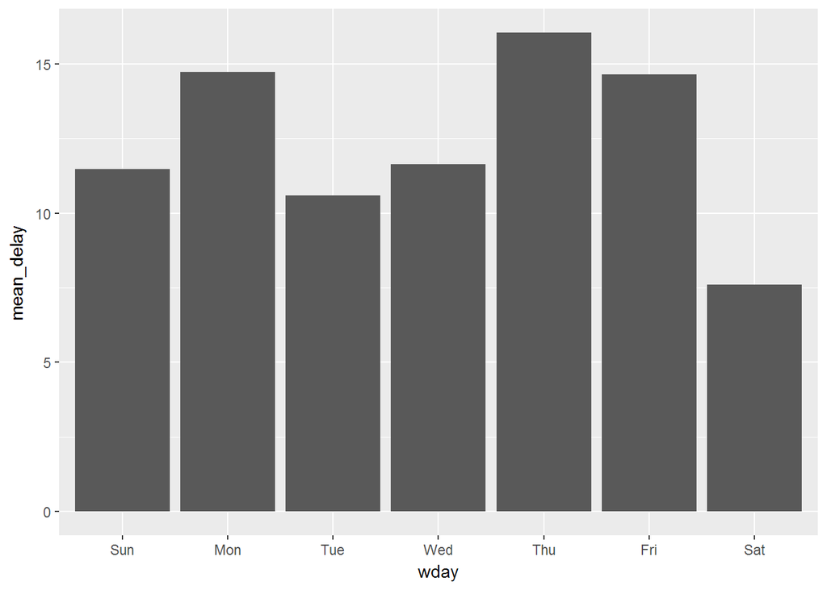

```r
flights %>%
  filter(!is.na(dep_time), !is.na(arr_time), !is.na(air_time)) %>%
  mutate(sched_dep_datetime = convert_to_datetime(year, month, day, sched_dep_time)) %>%
  select(sched_dep_datetime, dep_delay, flight) %>%
  mutate(wday = wday(sched_dep_datetime, label = T)) %>%
  group_by(wday) %>%
  summarise(mean_delay = mean(dep_delay)) %>%
  ggplot(aes(wday,mean_delay)) +
  geom_bar(stat = "identity")
```

Saturday looks good!

### 6. What makes distribution of diamonds$carat and flights$sched_dep_time similar?

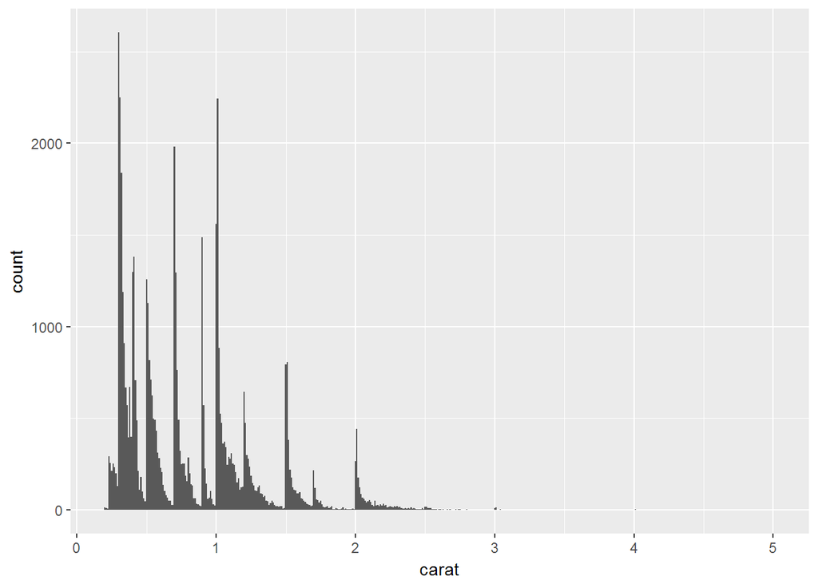

```r
ggplot(diamonds, aes(carat)) +
  geom_histogram(binwidth = 0.01)
```

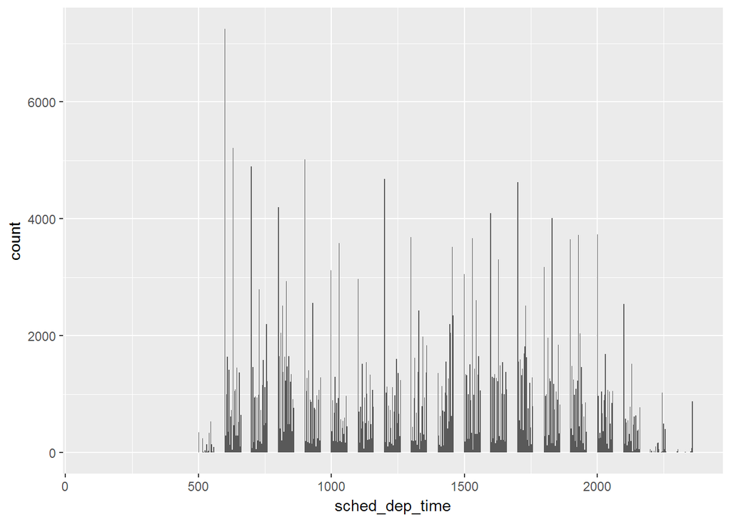

```r
ggplot(flights, aes(sched_dep_time)) +
  geom_histogram(binwidth = 3)
```

Rounding to whole numbers

### 7. Confirm the hypothesis that the early departures of flights in minutes 20-30 and 50-60 are caused by scheduled flights that leave early.

```r
breaks <- c(0:6)*10

flights %>%
  filter(!is.na(dep_time), !is.na(arr_time), !is.na(air_time)) %>%
  mutate(minute = sched_dep_time %% 100,
         minute = replace(minute, minute == 0, 60)) %>%
  select(minute, dep_delay) %>%
  mutate(is_delay = (dep_delay > 0),
         time_interval = cut(minute, breaks = breaks)) %>%
  group_by(time_interval) %>%
  summarise(delay_perc = sum(is_delay)/n())
```

```
## # A tibble: 6 x 2
##   time_interval delay_perc
##   <fct>              <dbl>
## 1 (0,10]             0.402
## 2 (10,20]            0.397
## 3 (20,30]            0.407
## 4 (30,40]            0.416
## 5 (40,50]            0.411
## 6 (50,60]            0.354
```

## Time spans

### 1. Why there is `months()` but no `dmonths()`?

Because the duration of each month is different.

### 2. Explain `days(overnight * 1)`, how does it work?

`T` and `F` will coerce to numerical.

### 3. Create a vector of dates giving the first day of every month in 2015. Create a vector giving the first day of every month in this year.

```r
ymd("20150101") + (0:11)*months(1)
```

```
##  [1] "2015-01-01" "2015-02-01" "2015-03-01" "2015-04-01" "2015-05-01"
##  [6] "2015-06-01" "2015-07-01" "2015-08-01" "2015-09-01" "2015-10-01"
## [11] "2015-11-01" "2015-12-01"
```

```r
ymd(paste0(year(today()),"01","01")) + (0:11)*months(1)
```

```
##  [1] "2018-01-01" "2018-02-01" "2018-03-01" "2018-04-01" "2018-05-01"
##  [6] "2018-06-01" "2018-07-01" "2018-08-01" "2018-09-01" "2018-10-01"
## [11] "2018-11-01" "2018-12-01"
```

### 4. Write a program gives the years according to your time entry.

```r
find_year_old <- function(birthday){
  (ymd(birthday) %--% today()) %/% dyears(1)
}

find_year_old("20010201")
```

```
## Note: method with signature 'Timespan#Timespan' chosen for function '%/%',
##  target signature 'Interval#Duration'.
##  "Interval#ANY" would also be valid
```

```
## [1] 16
```

### 5. Why can’t `today() %--% (today() + years(1)) / months(1)` work?

```r
(today() %--% (today() + years(1)) ) / months(1)
```

```
## [1] 12
```

It works!